# Risk Factor Analysis

## Outcome Variable

**Outcome Variable:** ever_swasted

## Predictor Variables

**Intervention Variable:** feducyrs

**Adjustment Set:**

- arm
- W_mage
- meducyrs
- hhwealth_quart
- W_mhtcm
- W_mwtkg
- W_mbmi
- W_gagebrth
- W_birthwt
- W_birthlen
- single
- delta_W_mage
- delta_meducyrs
- delta_hhwealth_quart
- delta_W_mhtcm
- delta_W_mwtkg
- delta_W_mbmi
- delta_W_gagebrth
- delta_W_birthwt
- delta_W_birthlen
- delta_single

## Stratifying Variables

The analysis was stratified on these variable(s):

- agecat
- studyid
- country

## Data Summary

| agecat | studyid | country | feducyrs | ever_swasted | n_cell | n |
| --- | --- | --- | --- | --- | --- | --- |
| 0-24 months | COHORTS | GUATEMALA | High | 0 | 214 | 1234 |
| 0-24 months | COHORTS | GUATEMALA | High | 1 | 17 | 1234 |
| 0-24 months | COHORTS | GUATEMALA | Low | 0 | 521 | 1234 |
| 0-24 months | COHORTS | GUATEMALA | Low | 1 | 37 | 1234 |
| 0-24 months | COHORTS | GUATEMALA | Medium | 0 | 411 | 1234 |
| 0-24 months | COHORTS | GUATEMALA | Medium | 1 | 34 | 1234 |
| 0-24 months | COHORTS | INDIA | High | 0 | 508 | 1447 |
| 0-24 months | COHORTS | INDIA | High | 1 | 59 | 1447 |
| 0-24 months | COHORTS | INDIA | Low | 0 | 434 | 1447 |
| 0-24 months | COHORTS | INDIA | Low | 1 | 38 | 1447 |
| 0-24 months | COHORTS | INDIA | Medium | 0 | 365 | 1447 |
| 0-24 months | COHORTS | INDIA | Medium | 1 | 43 | 1447 |
| 0-24 months | COHORTS | PHILIPPINES | High | 0 | 911 | 2868 |
| 0-24 months | COHORTS | PHILIPPINES | High | 1 | 117 | 2868 |
| 0-24 months | COHORTS | PHILIPPINES | Low | 0 | 726 | 2868 |
| 0-24 months | COHORTS | PHILIPPINES | Low | 1 | 100 | 2868 |
| 0-24 months | COHORTS | PHILIPPINES | Medium | 0 | 879 | 2868 |
| 0-24 months | COHORTS | PHILIPPINES | Medium | 1 | 135 | 2868 |
| 0-24 months | GMS-Nepal | NEPAL | High | 0 | 125 | 684 |
| 0-24 months | GMS-Nepal | NEPAL | High | 1 | 44 | 684 |
| 0-24 months | GMS-Nepal | NEPAL | Low | 0 | 210 | 684 |
| 0-24 months | GMS-Nepal | NEPAL | Low | 1 | 82 | 684 |
| 0-24 months | GMS-Nepal | NEPAL | Medium | 0 | 172 | 684 |
| 0-24 months | GMS-Nepal | NEPAL | Medium | 1 | 51 | 684 |
| 0-24 months | JiVitA-3 | BANGLADESH | High | 0 | 6118 | 25970 |
| 0-24 months | JiVitA-3 | BANGLADESH | High | 1 | 359 | 25970 |
| 0-24 months | JiVitA-3 | BANGLADESH | Low | 0 | 9936 | 25970 |
| 0-24 months | JiVitA-3 | BANGLADESH | Low | 1 | 701 | 25970 |
| 0-24 months | JiVitA-3 | BANGLADESH | Medium | 0 | 8344 | 25970 |
| 0-24 months | JiVitA-3 | BANGLADESH | Medium | 1 | 512 | 25970 |

[output cut: 90 more lines]

The following strata were considered:

- agecat: 0-24 months, studyid: COHORTS, country: GUATEMALA
- agecat: 0-24 months, studyid: COHORTS, country: INDIA
- agecat: 0-24 months, studyid: COHORTS, country: PHILIPPINES
- agecat: 0-24 months, studyid: GMS-Nepal, country: NEPAL
- agecat: 0-24 months, studyid: JiVitA-3, country: BANGLADESH
- agecat: 0-24 months, studyid: JiVitA-4, country: BANGLADESH
- agecat: 0-24 months, studyid: LCNI-5, country: MALAWI
- agecat: 0-24 months, studyid: MAL-ED, country: BANGLADESH
- agecat: 0-24 months, studyid: MAL-ED, country: INDIA
- agecat: 0-24 months, studyid: MAL-ED, country: NEPAL
- agecat: 0-24 months, studyid: MAL-ED, country: PERU
- agecat: 0-24 months, studyid: MAL-ED, country: SOUTH AFRICA
- agecat: 0-24 months, studyid: MAL-ED, country: TANZANIA, UNITED REPUBLIC OF
- agecat: 0-24 months, studyid: NIH-Crypto, country: BANGLADESH
- agecat: 0-24 months, studyid: PROBIT, country: BELARUS
- agecat: 0-24 months, studyid: PROVIDE, country: BANGLADESH
- agecat: 0-24 months, studyid: SAS-CompFeed, country: INDIA
- agecat: 0-24 months, studyid: SAS-FoodSuppl, country: INDIA
- agecat: 0-24 months, studyid: TanzaniaChild2, country: TANZANIA, UNITED REPUBLIC OF
- agecat: 0-24 months, studyid: ZVITAMBO, country: ZIMBABWE

### Dropped Strata

Some strata were dropped due to rare outcomes:

- agecat: 0-24 months, studyid: LCNI-5, country: MALAWI
- agecat: 0-24 months, studyid: MAL-ED, country: BANGLADESH
- agecat: 0-24 months, studyid: MAL-ED, country: INDIA
- agecat: 0-24 months, studyid: MAL-ED, country: NEPAL
- agecat: 0-24 months, studyid: MAL-ED, country: PERU
- agecat: 0-24 months, studyid: MAL-ED, country: SOUTH AFRICA
- agecat: 0-24 months, studyid: MAL-ED, country: TANZANIA, UNITED REPUBLIC OF

## Methods Detail

We're interested in the causal parameters $E[Y_a]$ for all values of $a \in \mathcal{A}$. These parameters represent the mean outcome if, possibly contrary to fact, we intervened to set all units to have $A=a$. Under the randomization and positivity assumptions, these are identified by the statistical parameters $\psi_a=E_W[E_{Y|A,W}(Y|A=a,W)]$. In addition, we're interested in the mean of $Y$, $E[Y]$ under no intervention (the observed mean). We will estimate these parameters by using SuperLearner to fit the relevant likelihood factors -- $E_{Y|A,W}(Y|A=a,W)$ and $p(A=a|W)$, and then updating our likelihood fit using a joint TMLE.

For unadjusted analyses ($W=\{\}$), initial likelihoods were estimated using Lrnr_glm to estimate the simple $E(Y|A)$ and Lrnr_mean to estimate $p(A)$. For adjusted analyses, a small library containing Lrnr_glmnet, Lrnr_xgboost, and Lrnr_mean was used.

Having estimated these parameters, we will then use the delta method to estimate relative risks and attributable risks relative to a prespecified baseline level of $A$.

# Results Detail

## Results Plots

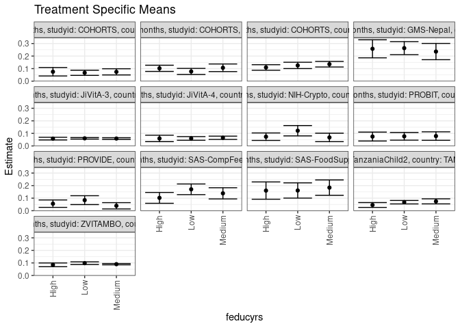

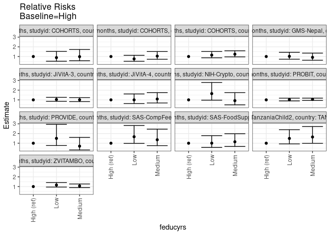

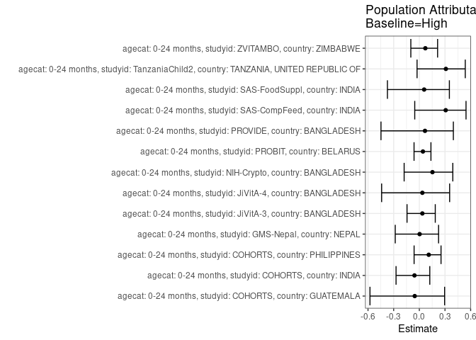

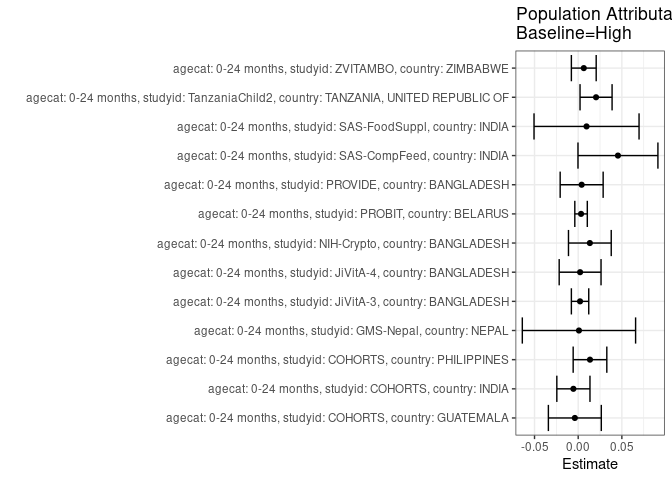

## Results Table

### Parameter: TSM

| agecat | studyid | country | intervention_level | baseline_level | estimate | ci_lower | ci_upper |
| --- | --- | --- | --- | --- | --- | --- | --- |
| 0-24 months | COHORTS | GUATEMALA | High | NA | 0.0751545 | 0.0414155 | 0.1088936 |
| 0-24 months | COHORTS | GUATEMALA | Low | NA | 0.0666940 | 0.0460700 | 0.0873179 |
| 0-24 months | COHORTS | GUATEMALA | Medium | NA | 0.0742101 | 0.0495514 | 0.0988689 |
| 0-24 months | COHORTS | INDIA | High | NA | 0.1022390 | 0.0775206 | 0.1269574 |
| 0-24 months | COHORTS | INDIA | Low | NA | 0.0774354 | 0.0532714 | 0.1015994 |
| 0-24 months | COHORTS | INDIA | Medium | NA | 0.1066570 | 0.0763785 | 0.1369355 |
| 0-24 months | COHORTS | PHILIPPINES | High | NA | 0.1092238 | 0.0872251 | 0.1312225 |
| 0-24 months | COHORTS | PHILIPPINES | Low | NA | 0.1254683 | 0.1002785 | 0.1506581 |
| 0-24 months | COHORTS | PHILIPPINES | Medium | NA | 0.1351840 | 0.1128541 | 0.1575139 |
| 0-24 months | GMS-Nepal | NEPAL | High | NA | 0.2578969 | 0.1859443 | 0.3298496 |
| 0-24 months | GMS-Nepal | NEPAL | Low | NA | 0.2632271 | 0.2112968 | 0.3151573 |
| 0-24 months | GMS-Nepal | NEPAL | Medium | NA | 0.2358642 | 0.1710780 | 0.3006504 |
| 0-24 months | JiVitA-3 | BANGLADESH | High | NA | 0.0583959 | 0.0477857 | 0.0690062 |
| 0-24 months | JiVitA-3 | BANGLADESH | Low | NA | 0.0605073 | 0.0543464 | 0.0666681 |
| 0-24 months | JiVitA-3 | BANGLADESH | Medium | NA | 0.0587969 | 0.0520826 | 0.0655112 |
| 0-24 months | JiVitA-4 | BANGLADESH | High | NA | 0.0597702 | 0.0343026 | 0.0852379 |
| 0-24 months | JiVitA-4 | BANGLADESH | Low | NA | 0.0597848 | 0.0452738 | 0.0742957 |
| 0-24 months | JiVitA-4 | BANGLADESH | Medium | NA | 0.0649883 | 0.0519089 | 0.0780677 |
| 0-24 months | NIH-Crypto | BANGLADESH | High | NA | 0.0737129 | 0.0438498 | 0.1035759 |
| 0-24 months | NIH-Crypto | BANGLADESH | Low | NA | 0.1212806 | 0.0800574 | 0.1625038 |
| 0-24 months | NIH-Crypto | BANGLADESH | Medium | NA | 0.0678379 | 0.0341962 | 0.1014797 |
| 0-24 months | PROBIT | BELARUS | High | NA | 0.0748077 | 0.0393914 | 0.1102240 |
| 0-24 months | PROBIT | BELARUS | Low | NA | 0.0766521 | 0.0460285 | 0.1072756 |
| 0-24 months | PROBIT | BELARUS | Medium | NA | 0.0787560 | 0.0448993 | 0.1126127 |
| 0-24 months | PROVIDE | BANGLADESH | High | NA | 0.0560345 | 0.0264189 | 0.0856501 |
| 0-24 months | PROVIDE | BANGLADESH | Low | NA | 0.0840336 | 0.0487611 | 0.1193061 |
| 0-24 months | PROVIDE | BANGLADESH | Medium | NA | 0.0391304 | 0.0140529 | 0.0642079 |
| 0-24 months | SAS-CompFeed | INDIA | High | NA | 0.1021586 | 0.0588882 | 0.1454291 |
| 0-24 months | SAS-CompFeed | INDIA | Low | NA | 0.1705240 | 0.1281060 | 0.2129421 |
| 0-24 months | SAS-CompFeed | INDIA | Medium | NA | 0.1385471 | 0.0940926 | 0.1830015 |
| 0-24 months | SAS-FoodSuppl | INDIA | High | NA | 0.1603000 | 0.0913183 | 0.2292816 |
| 0-24 months | SAS-FoodSuppl | INDIA | Low | NA | 0.1611622 | 0.1003972 | 0.2219272 |
| 0-24 months | SAS-FoodSuppl | INDIA | Medium | NA | 0.1840241 | 0.1228372 | 0.2452110 |
| 0-24 months | TanzaniaChild2 | TANZANIA, UNITED REPUBLIC OF | High | NA | 0.0454248 | 0.0260743 | 0.0647754 |
| 0-24 months | TanzaniaChild2 | TANZANIA, UNITED REPUBLIC OF | Low | NA | 0.0678614 | 0.0540311 | 0.0816917 |
| 0-24 months | TanzaniaChild2 | TANZANIA, UNITED REPUBLIC OF | Medium | NA | 0.0745748 | 0.0543936 | 0.0947559 |
| 0-24 months | ZVITAMBO | ZIMBABWE | High | NA | 0.0848438 | 0.0698630 | 0.0998245 |
| 0-24 months | ZVITAMBO | ZIMBABWE | Low | NA | 0.0982162 | 0.0875660 | 0.1088663 |
| 0-24 months | ZVITAMBO | ZIMBABWE | Medium | NA | 0.0901362 | 0.0849258 | 0.0953465 |

### Parameter: E(Y)

| agecat | studyid | country | intervention_level | baseline_level | estimate | ci_lower | ci_upper |
| --- | --- | --- | --- | --- | --- | --- | --- |
| 0-24 months | COHORTS | GUATEMALA | NA | NA | 0.0713128 | 0.0569485 | 0.0856771 |
| 0-24 months | COHORTS | INDIA | NA | NA | 0.0967519 | 0.0815150 | 0.1119888 |
| 0-24 months | COHORTS | PHILIPPINES | NA | NA | 0.1227336 | 0.1107225 | 0.1347447 |
| 0-24 months | GMS-Nepal | NEPAL | NA | NA | 0.2587719 | 0.2259267 | 0.2916172 |
| 0-24 months | JiVitA-3 | BANGLADESH | NA | NA | 0.0605314 | 0.0569870 | 0.0640758 |
| 0-24 months | JiVitA-4 | BANGLADESH | NA | NA | 0.0619670 | 0.0548012 | 0.0691329 |
| 0-24 months | NIH-Crypto | BANGLADESH | NA | NA | 0.0870712 | 0.0669870 | 0.1071555 |
| 0-24 months | PROBIT | BELARUS | NA | NA | 0.0780876 | 0.0455813 | 0.1105940 |
| 0-24 months | PROVIDE | BANGLADESH | NA | NA | 0.0600000 | 0.0423945 | 0.0776055 |
| 0-24 months | SAS-CompFeed | INDIA | NA | NA | 0.1476821 | 0.1188009 | 0.1765633 |
| 0-24 months | SAS-FoodSuppl | INDIA | NA | NA | 0.1698565 | 0.1338154 | 0.2058975 |
| 0-24 months | TanzaniaChild2 | TANZANIA, UNITED REPUBLIC OF | NA | NA | 0.0658833 | 0.0559209 | 0.0758458 |
| 0-24 months | ZVITAMBO | ZIMBABWE | NA | NA | 0.0912441 | 0.0863987 | 0.0960895 |

### Parameter: RR

| agecat | studyid | country | intervention_level | baseline_level | estimate | ci_lower | ci_upper |
| --- | --- | --- | --- | --- | --- | --- | --- |
| 0-24 months | COHORTS | GUATEMALA | High | High | 1.0000000 | 1.0000000 | 1.000000 |
| 0-24 months | COHORTS | GUATEMALA | Low | High | 0.8874243 | 0.5149179 | 1.529412 |
| 0-24 months | COHORTS | GUATEMALA | Medium | High | 0.9874339 | 0.5650566 | 1.725536 |
| 0-24 months | COHORTS | INDIA | High | High | 1.0000000 | 1.0000000 | 1.000000 |
| 0-24 months | COHORTS | INDIA | Low | High | 0.7573956 | 0.5102339 | 1.124284 |
| 0-24 months | COHORTS | INDIA | Medium | High | 1.0432122 | 0.7183359 | 1.515018 |
| 0-24 months | COHORTS | PHILIPPINES | High | High | 1.0000000 | 1.0000000 | 1.000000 |
| 0-24 months | COHORTS | PHILIPPINES | Low | High | 1.1487268 | 0.8686568 | 1.519096 |
| 0-24 months | COHORTS | PHILIPPINES | Medium | High | 1.2376786 | 0.9606766 | 1.594552 |
| 0-24 months | GMS-Nepal | NEPAL | High | High | 1.0000000 | 1.0000000 | 1.000000 |
| 0-24 months | GMS-Nepal | NEPAL | Low | High | 1.0206677 | 0.7251681 | 1.436581 |
| 0-24 months | GMS-Nepal | NEPAL | Medium | High | 0.9145676 | 0.6183354 | 1.352719 |
| 0-24 months | JiVitA-3 | BANGLADESH | High | High | 1.0000000 | 1.0000000 | 1.000000 |
| 0-24 months | JiVitA-3 | BANGLADESH | Low | High | 1.0361551 | 0.8488165 | 1.264840 |
| 0-24 months | JiVitA-3 | BANGLADESH | Medium | High | 1.0068666 | 0.8235101 | 1.231048 |
| 0-24 months | JiVitA-4 | BANGLADESH | High | High | 1.0000000 | 1.0000000 | 1.000000 |
| 0-24 months | JiVitA-4 | BANGLADESH | Low | High | 1.0002429 | 0.6206731 | 1.611937 |
| 0-24 months | JiVitA-4 | BANGLADESH | Medium | High | 1.0873026 | 0.6779784 | 1.743753 |
| 0-24 months | NIH-Crypto | BANGLADESH | High | High | 1.0000000 | 1.0000000 | 1.000000 |
| 0-24 months | NIH-Crypto | BANGLADESH | Low | High | 1.6453108 | 0.9693720 | 2.792579 |
| 0-24 months | NIH-Crypto | BANGLADESH | Medium | High | 0.9202996 | 0.4850711 | 1.746036 |
| 0-24 months | PROBIT | BELARUS | High | High | 1.0000000 | 1.0000000 | 1.000000 |
| 0-24 months | PROBIT | BELARUS | Low | High | 1.0246546 | 0.8919435 | 1.177112 |
| 0-24 months | PROBIT | BELARUS | Medium | High | 1.0527789 | 0.9409625 | 1.177883 |
| 0-24 months | PROVIDE | BANGLADESH | High | High | 1.0000000 | 1.0000000 | 1.000000 |
| 0-24 months | PROVIDE | BANGLADESH | Low | High | 1.4996768 | 0.7636284 | 2.945190 |
| 0-24 months | PROVIDE | BANGLADESH | Medium | High | 0.6983278 | 0.3042943 | 1.602599 |
| 0-24 months | SAS-CompFeed | INDIA | High | High | 1.0000000 | 1.0000000 | 1.000000 |
| 0-24 months | SAS-CompFeed | INDIA | Low | High | 1.6692079 | 0.9867781 | 2.823588 |
| 0-24 months | SAS-CompFeed | INDIA | Medium | High | 1.3561954 | 0.7495255 | 2.453907 |
| 0-24 months | SAS-FoodSuppl | INDIA | High | High | 1.0000000 | 1.0000000 | 1.000000 |
| 0-24 months | SAS-FoodSuppl | INDIA | Low | High | 1.0053788 | 0.5686648 | 1.777473 |
| 0-24 months | SAS-FoodSuppl | INDIA | Medium | High | 1.1479984 | 0.6669938 | 1.975881 |
| 0-24 months | TanzaniaChild2 | TANZANIA, UNITED REPUBLIC OF | High | High | 1.0000000 | 1.0000000 | 1.000000 |
| 0-24 months | TanzaniaChild2 | TANZANIA, UNITED REPUBLIC OF | Low | High | 1.4939267 | 0.9315433 | 2.395827 |
| 0-24 months | TanzaniaChild2 | TANZANIA, UNITED REPUBLIC OF | Medium | High | 1.6417177 | 0.9909525 | 2.719845 |
| 0-24 months | ZVITAMBO | ZIMBABWE | High | High | 1.0000000 | 1.0000000 | 1.000000 |
| 0-24 months | ZVITAMBO | ZIMBABWE | Low | High | 1.1576118 | 0.9471775 | 1.414798 |
| 0-24 months | ZVITAMBO | ZIMBABWE | Medium | High | 1.0623780 | 0.8896038 | 1.268708 |

### Parameter: PAR

| agecat | studyid | country | intervention_level | baseline_level | estimate | ci_lower | ci_upper |
| --- | --- | --- | --- | --- | --- | --- | --- |
| 0-24 months | COHORTS | GUATEMALA | High | NA | -0.0038417 | -0.0341373 | 0.0264538 |
| 0-24 months | COHORTS | INDIA | High | NA | -0.0054871 | -0.0244636 | 0.0134894 |
| 0-24 months | COHORTS | PHILIPPINES | High | NA | 0.0135098 | -0.0057535 | 0.0327731 |
| 0-24 months | GMS-Nepal | NEPAL | High | NA | 0.0008750 | -0.0639821 | 0.0657321 |
| 0-24 months | JiVitA-3 | BANGLADESH | High | NA | 0.0021354 | -0.0078045 | 0.0120754 |
| 0-24 months | JiVitA-4 | BANGLADESH | High | NA | 0.0021968 | -0.0217661 | 0.0261597 |
| 0-24 months | NIH-Crypto | BANGLADESH | High | NA | 0.0133584 | -0.0111179 | 0.0378346 |
| 0-24 months | PROBIT | BELARUS | High | NA | 0.0032799 | -0.0038758 | 0.0104357 |
| 0-24 months | PROVIDE | BANGLADESH | High | NA | 0.0039655 | -0.0206446 | 0.0285756 |
| 0-24 months | SAS-CompFeed | INDIA | High | NA | 0.0455235 | -0.0002380 | 0.0912849 |
| 0-24 months | SAS-FoodSuppl | INDIA | High | NA | 0.0095565 | -0.0505734 | 0.0696863 |
| 0-24 months | TanzaniaChild2 | TANZANIA, UNITED REPUBLIC OF | High | NA | 0.0204585 | 0.0021169 | 0.0388001 |
| 0-24 months | ZVITAMBO | ZIMBABWE | High | NA | 0.0064003 | -0.0078066 | 0.0206072 |

### Parameter: PAF

| agecat | studyid | country | intervention_level | baseline_level | estimate | ci_lower | ci_upper |
| --- | --- | --- | --- | --- | --- | --- | --- |
| 0-24 months | COHORTS | GUATEMALA | High | NA | -0.0538718 | -0.5770330 | 0.2957372 |
| 0-24 months | COHORTS | INDIA | High | NA | -0.0567132 | -0.2721285 | 0.1222247 |
| 0-24 months | COHORTS | PHILIPPINES | High | NA | 0.1100742 | -0.0611383 | 0.2536619 |
| 0-24 months | GMS-Nepal | NEPAL | High | NA | 0.0033813 | -0.2815714 | 0.2249759 |
| 0-24 months | JiVitA-3 | BANGLADESH | High | NA | 0.0352781 | -0.1437950 | 0.1863154 |
| 0-24 months | JiVitA-4 | BANGLADESH | High | NA | 0.0354510 | -0.4407003 | 0.3542343 |
| 0-24 months | NIH-Crypto | BANGLADESH | High | NA | 0.1534187 | -0.1775300 | 0.3913532 |
| 0-24 months | PROBIT | BELARUS | High | NA | 0.0420034 | -0.0617923 | 0.1356526 |
| 0-24 months | PROVIDE | BANGLADESH | High | NA | 0.0660920 | -0.4482931 | 0.3977847 |
| 0-24 months | SAS-CompFeed | INDIA | High | NA | 0.3082532 | -0.0536407 | 0.5458474 |
| 0-24 months | SAS-FoodSuppl | INDIA | High | NA | 0.0562622 | -0.3729464 | 0.3512921 |
| 0-24 months | TanzaniaChild2 | TANZANIA, UNITED REPUBLIC OF | High | NA | 0.3105261 | -0.0265946 | 0.5369406 |
| 0-24 months | ZVITAMBO | ZIMBABWE | High | NA | 0.0701452 | -0.0993762 | 0.2135267 |